# Project 2

Jeffrey Hu, Aaron Rock, Sanchit Vijay

12/14/2022

# Online Shoppers Dataset

## Introduction to our Dataset and Models

The “Online Shoppers Purchasing Intention Dataset” was found from the UCI archive and Kaggle, which was itself collected from Bahcesehir University in Istanbul, and gathered by the Inveon Information Technologies Consultancy and Trade in Istanbul. There are 12330 Observations, with 18 variables. We treated 17 of those columns as possible covariates in our models, and the remaining variable `Revenue`, was our response in all models. Our models were addressing whether the customer spent or not (represented by `Revenue` as a 1 and 0 respectively) based on the 17 features. These 17 features had a variety of available information, some from Google Analytics, and some from the website details/recorded cookies, which included the pages that the customer visited, how long they stayed on each page, their demographics, general page/website details, the website traffic at the time, and day/type of day when visited.

A big point of interest in our dataset was the unbalanced nature of our response variable. The greater majority (84.5%) of the consumers did not spend after their website visit, compared to a measly 15.5% who did. While this is easily explainable in the real world as a majority of website visitors can be expected to be e-window shopping rather than looking to make a purchase, this did increase the difficulty of the problem. We had to determine the best metric to use to determine our best model, and also look to the different ways to tackle the dataset so as to not under represent the information that predicts a possible buyer compared to a e-window shopper. In the end, given that both specificity and sensitivity would be innately imbalanced due to the `revenue` split, we decided to give up on accuracy as the metric for our model, and instead use AUC as the best metric going forward.

Finally, we decided to split our project into three possible models. We used Logistic Regression, Classification Trees, and K-Nearest Neighbors classification as the techniques to predict our response.

## Smart Questions

Our Research Topic/Question: What variables are strong predictors of the likelihood that a consumer will generate revenue on an e-commerce site? Can we build a convincing model to determine the likelihood of that revenue generation?

Specific: We will be measuring the probability/likelihood of an online consumer to spend on the e-commerce site based on their attributes.

Measurable: Our label or dependent variable will be `Revenue` with classification models, which will be measured by if they spend on the website before exiting, or if they don’t. Since our dataset is only taken from one unnamed e-commerce site, there could be unaccounted-for bias if we take the population that we’re measuring to be the whole of e-commerce visits. Likewise, this dataset was taken over a single year, so at certain points, there is unaccounted variation by seasonality or holidays where shoppers would purchase more or less. Still, the features in the dataset look to lessen this impact by adding in `Month`, `Weekend`, and `SpecialDay` variables.

Achievable: Despite there being 12330 observations, the computing power needed to generate a model and do exploratory data analysis is achievable, and with three people working in the allotted time frame, the dataset is more than manageable. Of course, the more computationally-expensive models, like the regression tree, may need to be limited in depth and possibilities in order to fit within our time frame.

Relevant: Our dataset is relevant because e-commerce shopping is incredibly popular with consumers. Nowadays, e-commerce companies heavily invest in AB testing, and the data/models provided from this project could give more insight into the direction that these companies would like to proceed in, in order to maximize their gains/appropriate metric.

Time-oriented: We will perform quick exploratory data analysis in the first half to gain a better understanding of the new dataset we have chosen, and then for the second half, build models for prediction.

# Logistic Models

## Initial Cleaning

In our initial .csv file, the data was already very clean and properly formatted for R to process. There were no NAs in the dataset, and no ommissions were made in the end. The only necessary bits of cleaning were to ensure that the variables were in the right data type to be inputted into the models.

```r
online_shoppers <- data.frame(read.csv("online_shoppers_intention.csv"))
str(online_shoppers)
dim(online_shoppers)
```

```r
which(is.na(online_shoppers))
online_shoppers <- na.omit(online_shoppers)
str(online_shoppers)
```

```r
online_shoppers$OperatingSystems = factor(online_shoppers$OperatingSystems)
online_shoppers$Browser = factor(online_shoppers$Browser)
online_shoppers$Region = factor(online_shoppers$Region)
online_shoppers$TrafficType = factor(online_shoppers$TrafficType)
online_shoppers$VisitorType = factor(online_shoppers$VisitorType)
online_shoppers$Weekend = factor(online_shoppers$Weekend)
online_shoppers$Revenue = factor(online_shoppers$Revenue)
# online_shoppers$Month = factor(online_shoppers$Month)
str(online_shoppers)
```

```
## 'data.frame':    12330 obs. of  18 variables:
##  $ Administrative         : int  0 0 0 0 0 0 0 1 0 0 ...
##  $ Administrative_Duration: num  0 0 0 0 0 0 0 0 0 0 ...
##  $ Informational          : int  0 0 0 0 0 0 0 0 0 0 ...
##  $ Informational_Duration : num  0 0 0 0 0 0 0 0 0 0 ...
##  $ ProductRelated         : int  1 2 1 2 10 19 1 0 2 3 ...
##  $ ProductRelated_Duration: num  0 64 0 2.67 627.5 ...
##  $ BounceRates            : num  0.2 0 0.2 0.05 0.02 ...
##  $ ExitRates              : num  0.2 0.1 0.2 0.14 0.05 ...
##  $ PageValues             : num  0 0 0 0 0 0 0 0 0 0 ...
##  $ SpecialDay             : num  0 0 0 0 0 0 0.4 0 0.8 0.4 ...
##  $ Month                  : chr  "Feb" "Feb" "Feb" "Feb" ...
##  $ OperatingSystems       : Factor w/ 8 levels "1","2","3","4",..: 1 2 4 3 3 2 2 1 2 2 ...
##  $ Browser                : Factor w/ 13 levels "1","2","3","4",..: 1 2 1 2 3 2 4 2 2 4 ...
##  $ Region                 : Factor w/ 9 levels "1","2","3","4",..: 1 1 9 2 1 1 3 1 2 1 ...
##  $ TrafficType            : Factor w/ 20 levels "1","2","3","4",..: 1 2 3 4 4 3 3 5 3 2 ...
##  $ VisitorType            : Factor w/ 3 levels "New_Visitor",..: 3 3 3 3 3 3 3 3 3 3 ...
##  $ Weekend                : Factor w/ 2 levels "FALSE","TRUE": 1 1 1 1 2 1 1 2 1 1 ...
##  $ Revenue                : Factor w/ 2 levels "FALSE","TRUE": 1 1 1 1 1 1 1 1 1 1 ...
```

## EDA Pre-logistic Regression

Let’s do an initial mixed corrplot to see the relationship between the features and the possibility of generating revenue. We will only look at the numerical/ordinal factors without the factors.

```r
library(corrplot)
online_shoppers_num = subset(online_shoppers, select = -c(Month, OperatingSystems, Browser, Region, TrafficType, VisitorType))
online_shoppers_num$Weekend = as.numeric(online_shoppers_num$Weekend)
online_shoppers_num$Revenue = as.numeric(online_shoppers_num$Revenue)
str(online_shoppers_num)
```

```
## 'data.frame':    12330 obs. of  12 variables:
##  $ Administrative         : int  0 0 0 0 0 0 0 1 0 0 ...
##  $ Administrative_Duration: num  0 0 0 0 0 0 0 0 0 0 ...
##  $ Informational          : int  0 0 0 0 0 0 0 0 0 0 ...
##  $ Informational_Duration : num  0 0 0 0 0 0 0 0 0 0 ...
##  $ ProductRelated         : int  1 2 1 2 10 19 1 0 2 3 ...
##  $ ProductRelated_Duration: num  0 64 0 2.67 627.5 ...
##  $ BounceRates            : num  0.2 0 0.2 0.05 0.02 ...
##  $ ExitRates              : num  0.2 0.1 0.2 0.14 0.05 ...
##  $ PageValues             : num  0 0 0 0 0 0 0 0 0 0 ...
##  $ SpecialDay             : num  0 0 0 0 0 0 0.4 0 0.8 0.4 ...
##  $ Weekend                : num  1 1 1 1 2 1 1 2 1 1 ...
##  $ Revenue                : num  1 1 1 1 1 1 1 1 1 1 ...
```

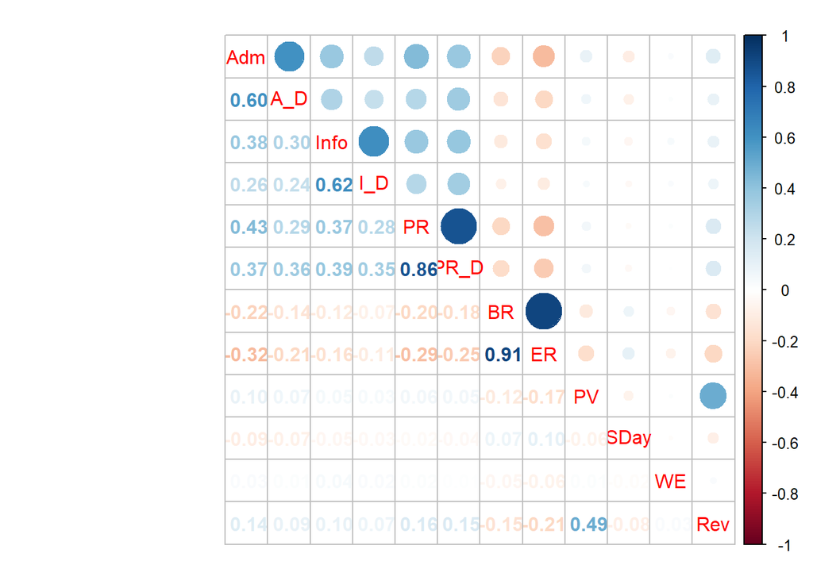

```r
shop_corr <- cor(online_shoppers_num)
colnames(shop_corr) <- c("Adm", "A_D", "Info", "I_D", "PR", "PR_D", "BR", "ER", "PV", "SDay", "WE", "Rev")
corrplot.mixed(shop_corr)
```

We observed some very obvious correlation between things like the number of administrative pages visited and the amount of time each visitor spent on administrative pages, which is expected just like `informational`/`informational_duration` and `productedRelated`/`productRelated_Duration`.

The highest correlation with our response is the `PageValues`, which had a .49 correlation with Revenue. Again, this higher correlation makes sense because the `PageValues` feature is an average value/metric of the page visited before the user completed a transaction.

Other than that, the Bounce and Exit Rates both have a negative correlation with the likelihood of generating revenue, while users that visited `productRelated` pages seems to more likely generate revenue over users that visited admin or informational pages.

Below, we continue with a t-test to see if the `PageValues` covariate average value differs for those who spent on the website, and those who did not.

```r
online_shopper_bought <- online_shoppers[which(online_shoppers$Revenue==TRUE),]
online_shopper_not <- online_shoppers[which(online_shoppers$Revenue==FALSE),]
t.test(online_shopper_bought$PageValues, online_shopper_not$PageValues, conf.level = .95)
```

```
##
##  Welch Two Sample t-test
##
## data:  online_shopper_bought$PageValues and online_shopper_not$PageValues
## t = 31, df = 1954, p-value <2e-16
## alternative hypothesis: true difference in means is not equal to 0
## 95 percent confidence interval:
##  23.7 26.9
## sample estimates:
## mean of x mean of y
##     27.26      1.98
```

From the t-test, we reject the null, and bring strong evidence to support the alternative hypothesis that the `PageValue` covariate has a strong effect on whether or not the shopper buys.

## Initial Logistic Regression

Here is the initial logistic regression using the correlation plot to select features. Generally, the covariates with the highest correlations with the response were selected, without including both pairs of the covariates that have high correlation with each other. For example, while `ProductRelated` and `Product_Duration` could both be predictors of `Revenue`, they have high correlation with each other, and `Product_Duration` is not included.

```r
unloadPkg("caret")
attach(online_shoppers)
ShopLogit <- glm(Revenue ~ PageValues + ProductRelated + Informational + Administrative + ExitRates, data = online_shoppers, family = "binomial")
summary(ShopLogit)
```

```
##
## Call:
## glm(formula = Revenue ~ PageValues + ProductRelated + Informational +
##     Administrative + ExitRates, family = "binomial", data = online_shoppers)
##
## Deviance Residuals:
##    Min      1Q  Median      3Q     Max
## -5.997  -0.473  -0.387  -0.199   3.409
##
## Coefficients:
##                 Estimate Std. Error z value Pr(>|z|)
## (Intercept)    -2.04e+00   6.62e-02  -30.79   <2e-16 ***
## PageValues      7.99e-02   2.32e-03   34.42   <2e-16 ***
## ProductRelated  5.16e-03   5.89e-04    8.77   <2e-16 ***
## Informational   3.52e-02   2.17e-02    1.62     0.10
## Administrative  5.55e-04   9.21e-03    0.06     0.95
## ExitRates      -1.89e+01   1.62e+00  -11.67   <2e-16 ***
## ---
## Signif. codes:  0 '***' 0.001 '**' 0.01 '*' 0.05 '.' 0.1 ' ' 1
##
## (Dispersion parameter for binomial family taken to be 1)
##
##     Null deviance: 10624.8  on 12329  degrees of freedom
## Residual deviance:  7448.3  on 12324  degrees of freedom
## AIC: 7460
##
## Number of Fisher Scoring iterations: 6
```

```r
#kabledply(confusionMatrix(actual=ShopLogit$y,predicted=ShopLogit$fitted.values), title = "Confusion Matrix")
confusionMatrix(actual=ShopLogit$y,predicted=ShopLogit$fitted.values)
```

```
##       [,1] [,2]
## [1,] 10192 1205
## [2,]   230  703
```

```r
prob = predict(ShopLogit, type = "response")
h <- roc(Revenue~prob)
auc(h)
```

```
## Area under the curve: 0.882
```

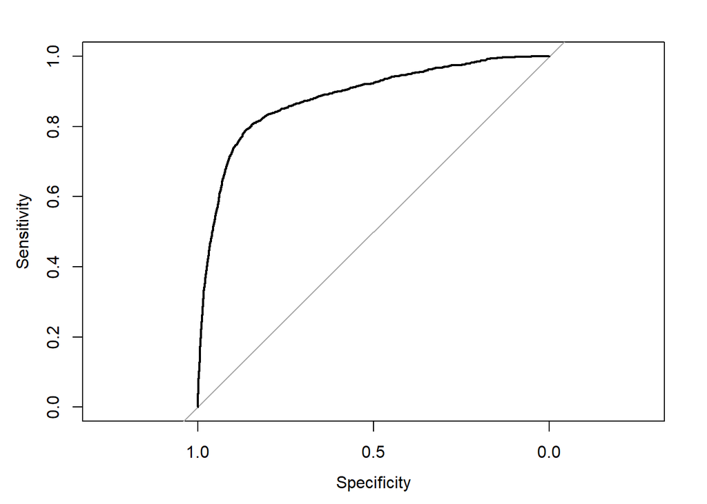

```r
plot(h)
```

```r
ShopperNullLogit <- glm(Revenue ~ 1, family = "binomial")
mcFadden = 1 - logLik(ShopLogit)/logLik(ShopperNullLogit)
mcFadden
```

```
## 'log Lik.' 0.299 (df=6)
```

```r
pR2(ShopLogit)
```

```
## fitting null model for pseudo-r2
```

```
##       llh   llhNull        G2  McFadden      r2ML      r2CU
## -3724.131 -5312.398  3176.535     0.299     0.227     0.393
```

```r
loadPkg("caret")
```

## Logistic Regression with the Full Model and K-NN cross validation.

```r
set.seed(123)
train_control <- trainControl(method = "cv", number = 10)
ShopModelCV <- train(Revenue ~., data = online_shoppers, method = "glm", family = "binomial", trControl = train_control)
summary(ShopModelCV)
```

```r
unloadPkg("caret")
xkabledply(confusionMatrix(actual=ShopModelCV$finalModel$y,predicted=ShopModelCV$finalModel$fitted.values), title = "Confusion Matrix")
```

Confusion Matrix

| 1 | 2 |
| --- | --- |
| 10176 | 1164 |
| 246 | 744 |

```r
prob = predict(ShopModelCV$finalModel, type = "response")
h <- roc(Revenue~prob)
auc(h)
```

```
## Area under the curve: 0.9
```

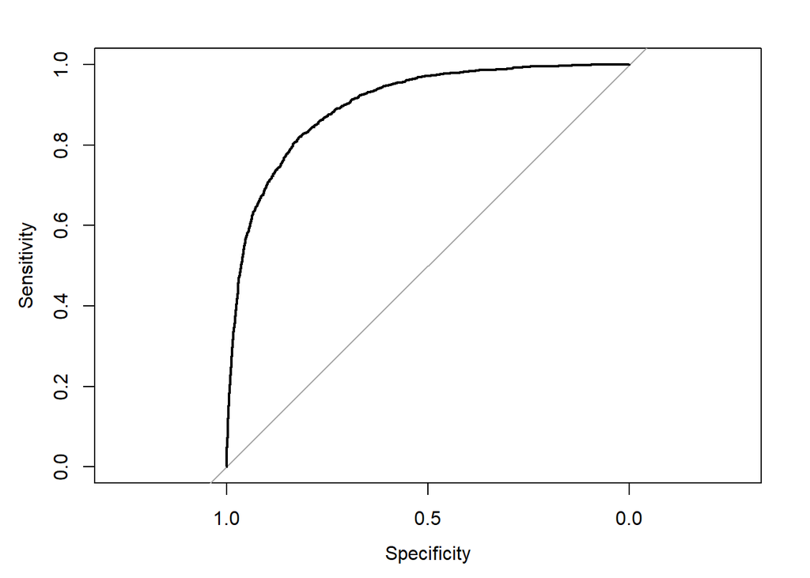

```r
plot(h)
```

```r
ShopperNullLogit <- glm(Revenue ~ 1, family = "binomial")
mcFadden = 1 - logLik(ShopModelCV$finalModel)/logLik(ShopperNullLogit)
mcFadden
```

```
## 'log Lik.' 0.334 (df=68)
```

```r
loadPkg("caret")
```

## Logistic Regression with the Reduced Model and K-NN cross validation.

Finally, let’s reduce the number of features in this model, particularly the less significant ones that might be causing overfitting. Starting from the null model, let’s add the strongest predictors and move in both directions to achieve the best AIC.

```r
full = ShopModelCV
null = glm(Revenue ~ 1, family = "binomial")
step(null, scope = list(lower=null, upper=full), direction = "both", criterion = "AIC")
```

Now we have our reduced logistic model, which is glm(formula = Revenue ~ PageValues + Month + ExitRates + ProductRelated_Duration + TrafficType + VisitorType + ProductRelated, family = “binomial”)

```r
ShopModelCV <- train(Revenue ~ PageValues + Month + ExitRates + ProductRelated_Duration + TrafficType + VisitorType + ProductRelated, data = online_shoppers, method = "glm", family = "binomial", trControl = train_control)
summary(ShopModelCV)
```

```
##
## Call:
## NULL
##
## Deviance Residuals:
##    Min      1Q  Median      3Q     Max
## -6.146  -0.464  -0.328  -0.155   3.126
##
## Coefficients:
##                               Estimate Std. Error z value Pr(>|z|)
## (Intercept)                  -1.80e+00   1.94e-01   -9.27  < 2e-16 ***
## PageValues                    8.17e-02   2.40e-03   34.04  < 2e-16 ***
## MonthDec                     -7.10e-01   1.86e-01   -3.81  0.00014 ***
## MonthFeb                     -1.78e+00   6.44e-01   -2.76  0.00580 **
## MonthJul                      1.07e-01   2.19e-01    0.49  0.62534
## MonthJune                    -3.41e-01   2.77e-01   -1.23  0.21798
## MonthMar                     -5.73e-01   1.85e-01   -3.10  0.00194 **
## MonthMay                     -5.53e-01   1.71e-01   -3.23  0.00123 **
## MonthNov                      4.45e-01   1.67e-01    2.67  0.00758 **
## MonthOct                     -6.32e-02   2.04e-01   -0.31  0.75640
## MonthSep                     -8.51e-03   2.13e-01   -0.04  0.96809
## ExitRates                    -1.63e+01   1.67e+00   -9.77  < 2e-16 ***
## ProductRelated_Duration       6.57e-05   2.61e-05    2.52  0.01182 *
## TrafficType2                  1.83e-01   9.39e-02    1.94  0.05195 .
## TrafficType3                 -2.51e-01   1.23e-01   -2.04  0.04129 *
## TrafficType4                  4.32e-02   1.39e-01    0.31  0.75672
## TrafficType5                  2.52e-01   2.13e-01    1.18  0.23659
## TrafficType6                 -8.73e-02   1.97e-01   -0.44  0.65807
## TrafficType7                  3.48e-01   4.72e-01    0.74  0.46088
## TrafficType8                  5.83e-01   1.77e-01    3.29  0.00101 **
## TrafficType9                 -3.11e-02   6.71e-01   -0.05  0.96303
## TrafficType10                 3.50e-01   1.65e-01    2.12  0.03402 *
## TrafficType11                 4.07e-01   2.10e-01    1.94  0.05230 .
## TrafficType12                -1.19e+01   1.46e+03   -0.01  0.99348
## TrafficType13                -6.02e-01   1.98e-01   -3.04  0.00235 **
## TrafficType14                -4.32e-01   1.07e+00   -0.40  0.68668
## TrafficType15                -1.23e+01   2.21e+02   -0.06  0.95539
## TrafficType16                 1.95e+00   1.24e+00    1.58  0.11520
## TrafficType17                -1.18e+01   1.46e+03   -0.01  0.99354
## TrafficType18                -1.25e+01   4.45e+02   -0.03  0.97758
## TrafficType19                -1.14e+00   1.41e+00   -0.81  0.41803
## TrafficType20                 4.58e-01   2.61e-01    1.76  0.07901 .
## VisitorTypeOther             -5.83e-01   5.43e-01   -1.07  0.28311
## VisitorTypeReturning_Visitor -2.14e-01   9.03e-02   -2.37  0.01789 *
## ProductRelated                2.04e-03   1.12e-03    1.83  0.06794 .
## ---
## Signif. codes:  0 '***' 0.001 '**' 0.01 '*' 0.05 '.' 0.1 ' ' 1
##
## (Dispersion parameter for binomial family taken to be 1)
##
##     Null deviance: 10624.8  on 12329  degrees of freedom
## Residual deviance:  7112.9  on 12295  degrees of freedom
## AIC: 7183
##
## Number of Fisher Scoring iterations: 14
```

The new AIC of the model is 7182.9, which is a noticeable improvement on the original full model of 7214.7. Let’s apply it to the test data (4:1 on random seed 123) and see how it does.

```r
unloadPkg("caret")
xkabledply(confusionMatrix(actual=ShopModelCV$finalModel$y,predicted=ShopModelCV$finalModel$fitted.values), title = "Confusion Matrix")
```

Confusion Matrix

| 1 | 2 |
| --- | --- |
| 10177 | 1168 |
| 245 | 740 |

```r
prob = predict(ShopModelCV$finalModel, type = "response")
h <- roc(Revenue~prob)
auc(h)
```

```
## Area under the curve: 0.899
```

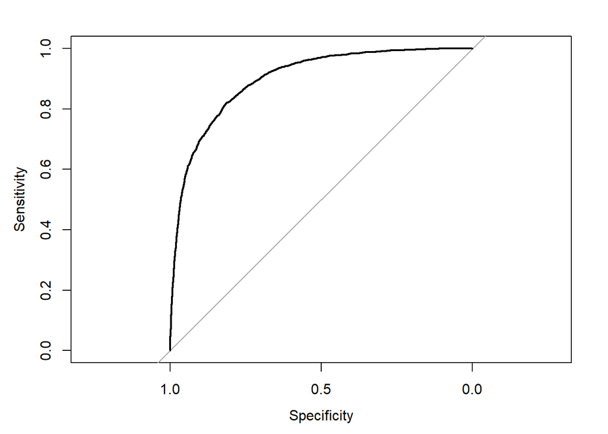

```r
plot(h)
```

```r
ShopperNullLogit <- glm(Revenue ~ 1, family = "binomial")
mcFadden = 1 - logLik(ShopModelCV$finalModel)/logLik(ShopperNullLogit)
mcFadden
```

```
## 'log Lik.' 0.331 (df=35)
```

Finally, let’s move the cutoff value to get a high sensitivity without sacrificing too much accuracy. Let’s try lowering it to .2.

```r
xkabledply(confusionMatrix(actual=ShopModelCV$finalModel$y,predicted=ShopModelCV$finalModel$fitted.values, cutoff=.2), title = "Confusion Matrix")
```

Confusion Matrix

| 1 | 2 |
| --- | --- |
| 9331 | 561 |
| 1091 | 1347 |

```r
prob = predict(ShopModelCV$finalModel, type = "response")
h <- roc(Revenue~prob)
auc(h)
```

```
## Area under the curve: 0.899
```

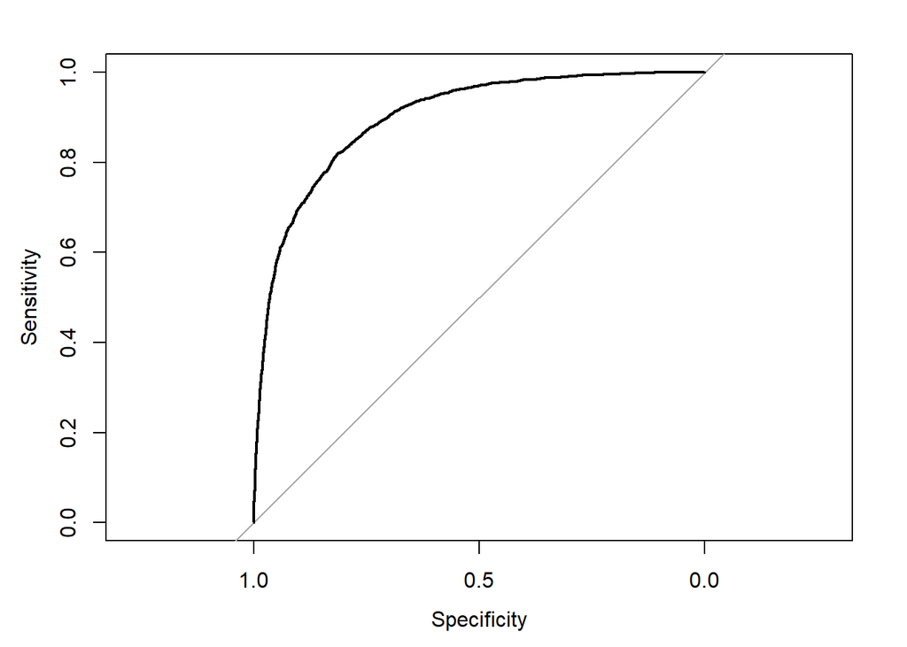

```r
plot(h)
```

```r
ShopperNullLogit <- glm(Revenue ~ 1, family = "binomial")
mcFadden = 1 - logLik(ShopModelCV$finalModel)/logLik(ShopperNullLogit)
mcFadden
```

```
## 'log Lik.' 0.331 (df=35)
```

## Interpretation and Model Comparison

All of the models had generally high accuracies and AUCs, but I would choose the final model as it has the lowest AIC out of the three models. While the McFadden and AUC of the full model was slightly higher than that of the reduced model, as the complexity is much less with only 7 out of the possible 17 different features, the lower complexity and balance between underfitting and overfitting between the initial and full model has me leaning more towards the reduced model. Lastly, by sacrificing accuracy, it is possible to greatly increase the true positive rate, though it will increase the false positive rate a bit. Again, so long as the AUC is good and the ROC curve is smooth throughout, the cutoff rate can be adjusted depending on the standards/metric of the e-commerce business at hand.

# Classification Tree and Oversampling

```r
#First, load the file
df_orig = data.frame(read.csv("online_shoppers_intention.csv"))
head(df_orig)
```

```
##   Administrative Administrative_Duration Informational Informational_Duration
## 1              0                       0             0                      0
## 2              0                       0             0                      0
## 3              0                       0             0                      0
## 4              0                       0             0                      0
## 5              0                       0             0                      0
## 6              0                       0             0                      0
##   ProductRelated ProductRelated_Duration BounceRates ExitRates PageValues
## 1              1                    0.00      0.2000    0.2000          0
## 2              2                   64.00      0.0000    0.1000          0
## 3              1                    0.00      0.2000    0.2000          0
## 4              2                    2.67      0.0500    0.1400          0
## 5             10                  627.50      0.0200    0.0500          0
## 6             19                  154.22      0.0158    0.0246          0
##   SpecialDay Month OperatingSystems Browser Region TrafficType
## 1          0   Feb                1       1      1           1
## 2          0   Feb                2       2      1           2
## 3          0   Feb                4       1      9           3
## 4          0   Feb                3       2      2           4
## 5          0   Feb                3       3      1           4
## 6          0   Feb                2       2      1           3
##         VisitorType Weekend Revenue
## 1 Returning_Visitor   FALSE   FALSE
## 2 Returning_Visitor   FALSE   FALSE
## 3 Returning_Visitor   FALSE   FALSE
## 4 Returning_Visitor   FALSE   FALSE
## 5 Returning_Visitor    TRUE   FALSE
## 6 Returning_Visitor   FALSE   FALSE
```

```r
colSums(is.na(df_orig))
```

```
##          Administrative Administrative_Duration           Informational
##                       0                       0                       0
##  Informational_Duration          ProductRelated ProductRelated_Duration
##                       0                       0                       0
##             BounceRates               ExitRates              PageValues
##                       0                       0                       0
##              SpecialDay                   Month        OperatingSystems
##                       0                       0                       0
##                 Browser                  Region             TrafficType
##                       0                       0                       0
##             VisitorType                 Weekend                 Revenue
##                       0                       0                       0
```

No null values in the dataset.

```r
table(df_orig$Revenue)
```

```
##
## FALSE  TRUE
## 10422  1908
```

We can see there is an imbalance in dataset. True values are less than 20% as compared to the False values.

## Factoring categorical variables

We will factor our categorical variables.

```r
df = data.frame(df_orig)

df$VisitorType = factor(df$VisitorType)
df$Weekend = factor(df$Weekend)
df$Revenue = factor(df$Revenue)
df$Month = factor(df$Month)

df[, c('VisitorType', 'Weekend', 'Revenue', 'Month')] <- sapply(df[, c('VisitorType', 'Weekend', 'Revenue', 'Month')], unclass)

df$VisitorType = factor(df$VisitorType)
df$Weekend = factor(df$Weekend)
df$Revenue = factor(df$Revenue)
df$Month = factor(df$Month)

head(df)
```

```
##   Administrative Administrative_Duration Informational Informational_Duration
## 1              0                       0             0                      0
## 2              0                       0             0                      0
## 3              0                       0             0                      0
## 4              0                       0             0                      0
## 5              0                       0             0                      0
## 6              0                       0             0                      0
##   ProductRelated ProductRelated_Duration BounceRates ExitRates PageValues
## 1              1                    0.00      0.2000    0.2000          0
## 2              2                   64.00      0.0000    0.1000          0
## 3              1                    0.00      0.2000    0.2000          0
## 4              2                    2.67      0.0500    0.1400          0
## 5             10                  627.50      0.0200    0.0500          0
## 6             19                  154.22      0.0158    0.0246          0
##   SpecialDay Month OperatingSystems Browser Region TrafficType VisitorType
## 1          0     3                1       1      1           1           3
## 2          0     3                2       2      1           2           3
## 3          0     3                4       1      9           3           3
## 4          0     3                3       2      2           4           3
## 5          0     3                3       3      1           4           3
## 6          0     3                2       2      1           3           3
##   Weekend Revenue
## 1       1       1
## 2       1       1
## 3       1       1
## 4       1       1
## 5       2       1
## 6       1       1
```

## EDA

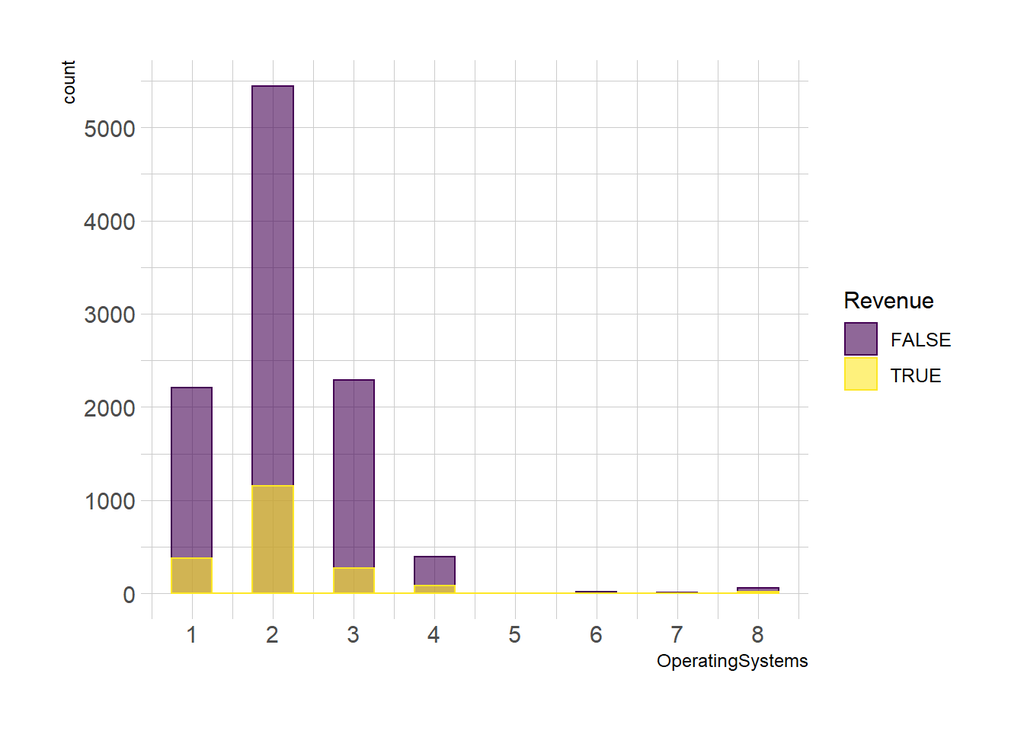

```r
ggplot(df_orig, aes(x=OperatingSystems, color=Revenue, fill=Revenue)) +
  # geom_histogram(bins = 8, fill="pink") +
  # geom_freqpoly(bins=8, color="red") +
  geom_histogram(binwidth = 0.5, alpha=0.6, position = 'identity') +
  scale_color_viridis(discrete=TRUE) +
  scale_fill_viridis(discrete=TRUE) +
  scale_x_continuous(breaks=1:8) + scale_y_continuous(n.breaks=6) +
  theme_ipsum()
```

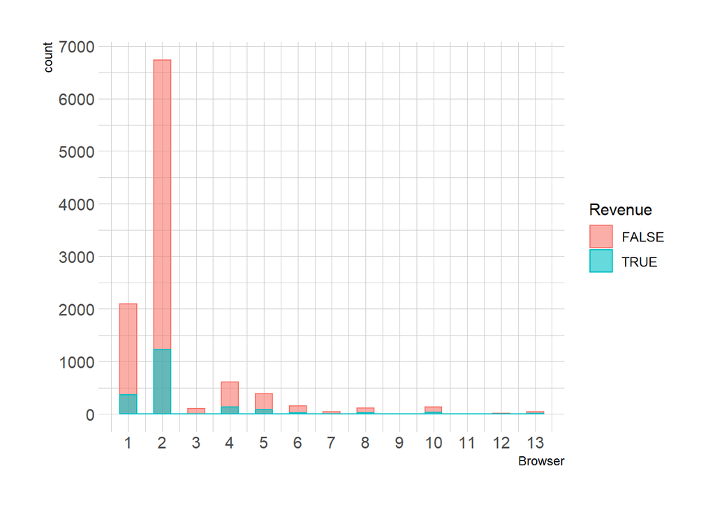

```r
ggplot(df_orig, aes(x=Browser, color=Revenue, fill=Revenue)) +
  geom_histogram(binwidth = 0.5, alpha=0.6, position = 'identity') +
  scale_x_continuous(breaks=1:13, ) + scale_y_continuous(n.breaks=6) +
  theme_ipsum()
```

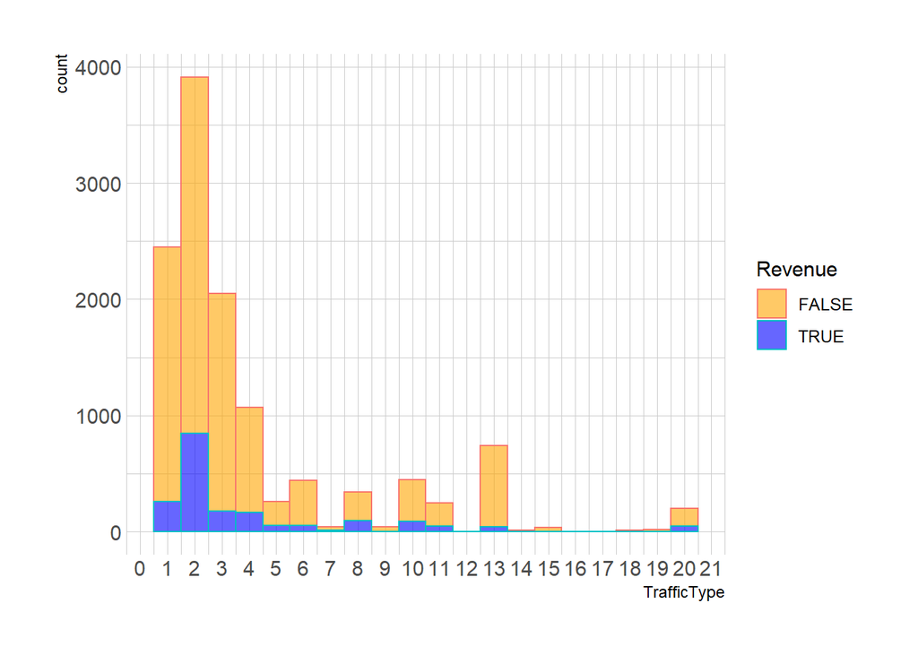

```r
ggplot(df_orig, aes(x=TrafficType, color=Revenue, fill=Revenue)) +
  geom_histogram(binwidth = 1, alpha=0.6) +
  scale_fill_manual(values=c("orange", "blue")) +
  scale_x_continuous(n.breaks=20) + scale_y_continuous(n.breaks=6) +
  theme_ipsum()
```

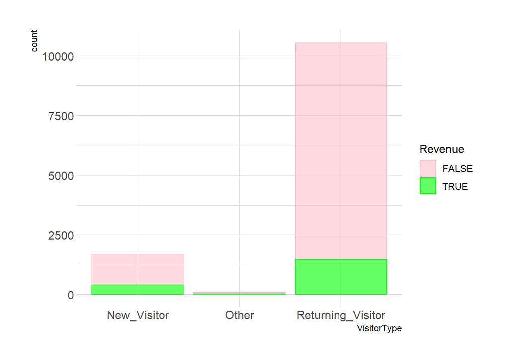

```r
ggplot(df_orig, aes(x=VisitorType, color=Revenue, fill=Revenue)) +
  geom_histogram(alpha=0.6, stat="count") +
  scale_fill_manual(values=c("pink", "green")) + scale_color_manual(values=c("pink", "green")) +
  theme_ipsum()
```

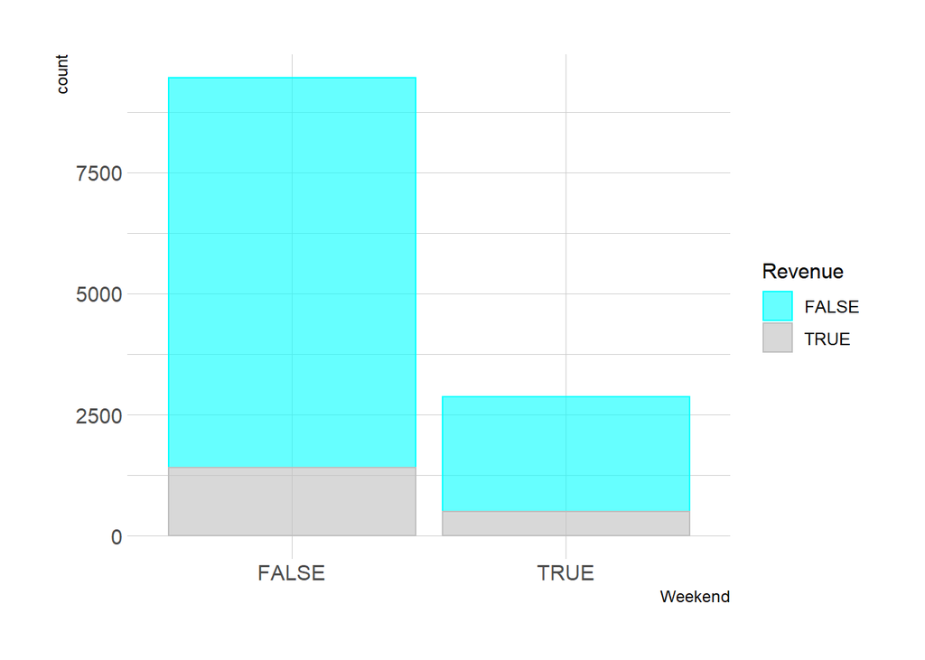

```r
ggplot(df_orig, aes(x=Weekend, color=Revenue, fill=Revenue)) +
  geom_histogram(alpha=0.6, stat="count") +
  scale_fill_manual(values=c("cyan", "gray")) + scale_color_manual(values=c("cyan", "gray")) +
  theme_ipsum()
```

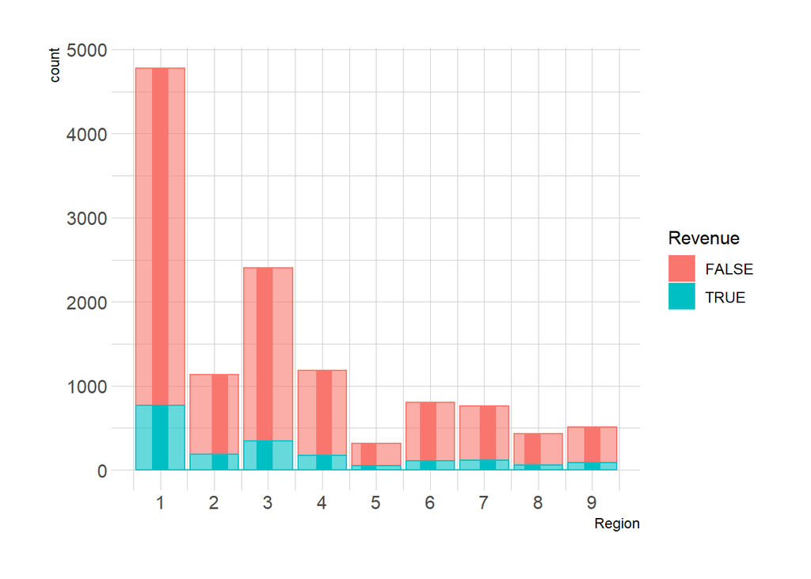

```r
ggplot(df_orig, aes(x=Region, color=Revenue, fill=Revenue)) +
  geom_histogram(binwidth = 1, alpha=0.6, stat="count") + stat_bin(center=1) +
  scale_x_continuous(breaks=1:13, ) + scale_y_continuous(n.breaks=6) +
  theme_ipsum()
```

Plotting highlights the imbalance between positive and negative classes in our response variable (Revenue). The distribution is also right skewed. In the histogram of `weekend` we can see there are more ones in `Revenue` over weekdays as compared to weekends.

## Inferential Statistics

We will perform Chi-Square test on all the last 6 categorical variables. For the variables with simulated p-value parameter False, the p-value is computed from the asymptotic chi-squared distribution of the test statistic. Otherwise, for variables without normal distribution p-value is calculated using Monte-Carlo simulations.

```r
os_contable = table(df_orig$Revenue, df_orig$OperatingSystems)
# os_contable
chisq.test(os_contable, simulate.p.value=T)
```

```
##
##  Pearson's Chi-squared test with simulated p-value (based on 2000
##  replicates)
##
## data:  os_contable
## X-squared = 75, df = NA, p-value = 5e-04
```

```r
br_contable = table(df_orig$Revenue, df_orig$Browser)
# br_contable
chisq.test(br_contable, simulate.p.value=T)
```

```
##
##  Pearson's Chi-squared test with simulated p-value (based on 2000
##  replicates)
##
## data:  br_contable
## X-squared = 28, df = NA, p-value = 0.008
```

```r
rg_contable = table(df_orig$Revenue, df_orig$Region)
# rg_contable
chisq.test(rg_contable, simulate.p.value=F)
```

```
##
##  Pearson's Chi-squared test
##
## data:  rg_contable
## X-squared = 9, df = 8, p-value = 0.3
```

```r
Tt_contable = table(df_orig$Revenue, df_orig$TrafficType)
# Tt_contable
chisq.test(Tt_contable, simulate.p.value=T)
```

```
##
##  Pearson's Chi-squared test with simulated p-value (based on 2000
##  replicates)
##
## data:  Tt_contable
## X-squared = 373, df = NA, p-value = 5e-04
```

```r
Vt_contable = table(df_orig$Revenue, df_orig$VisitorType)
Vt_contable
```

```
##
##         New_Visitor Other Returning_Visitor
##   FALSE        1272    69              9081
##   TRUE          422    16              1470
```

```r
chisq.test(Vt_contable, simulate.p.value=F)
```

```
##
##  Pearson's Chi-squared test
##
## data:  Vt_contable
## X-squared = 135, df = 2, p-value <2e-16
```

```r
wk_contable = table(df_orig$Revenue, df_orig$Weekend)
# wk_contable
chisq.test(wk_contable, simulate.p.value=F)
```

```
##
##  Pearson's Chi-squared test with Yates' continuity correction
##
## data:  wk_contable
## X-squared = 10, df = 1, p-value = 0.001
```

From above testing, all the variables except Region are statistically significant (p-value < 0.05). Region has p-value of 0.3 (>0.05) making it statistically insignificant. Hence we will omit the Region variable from our modeling.

```r
set.seed(1234)
df_sample <- sample(2, nrow(df), replace=TRUE, prob=c(0.80, 0.20))

train <- df[df_sample==1, ]

test <- df[df_sample==2, ]
```

## Classification Tree Modeling and Hyperparameter Tuning

We will choose “maxdepth” parameter for our decision tree. For this we will be using original unbalanced dataset only.

```r
loadPkg("rpart")
loadPkg("caret")
confusionMatrixResultDf = data.frame( Depth=numeric(0), Accuracy= numeric(0), Sensitivity=numeric(0), Specificity=numeric(0), Pos.Pred.Value=numeric(0), Neg.Pred.Value=numeric(0), Precision=numeric(0), Recall=numeric(0), F1=numeric(0), Prevalence=numeric(0), Detection.Rate=numeric(0), Detection.Prevalence=numeric(0), Balanced.Accuracy=numeric(0), row.names = NULL )

for (deep in 2:7) {
  tree_fit <- rpart(Revenue ~ . - Region, data=train, method="class", control = list(maxdepth = deep, cp=0.005))

  cm = confusionMatrix(predict(tree_fit, test, type = "class"), reference = test$Revenue, positive = "2")

  cmaccu = cm$overall['Accuracy']

  cmt = data.frame(Depth=deep, Accuracy = cmaccu, row.names = NULL)
  cmt = cbind( cmt, data.frame( t(cm$byClass)))
  confusionMatrixResultDf = rbind(confusionMatrixResultDf, cmt)

}

xkabledply(confusionMatrixResultDf, title="Kyphosis Classification Trees summary with varying MaxDepth")
```

| Depth | Accuracy | Sensitivity | Specificity | Pos.Pred.Value | Neg.Pred.Value | Precision | Recall | F1 | Prevalence | Detection.Rate | Detection.Prevalence | Balanced.Accuracy |
| --- | --- | --- | --- | --- | --- | --- | --- | --- | --- | --- | --- | --- |
| 2 | 0.876 | 0.387 | 0.972 | 0.724 | 0.891 | 0.724 | 0.387 | 0.504 | 0.163 | 0.0628 | 0.0867 | 0.679 |
| 3 | 0.881 | 0.571 | 0.941 | 0.652 | 0.919 | 0.652 | 0.571 | 0.609 | 0.163 | 0.0928 | 0.1422 | 0.756 |
| 4 | 0.886 | 0.539 | 0.954 | 0.695 | 0.914 | 0.695 | 0.539 | 0.607 | 0.163 | 0.0875 | 0.1260 | 0.746 |
| 5 | 0.885 | 0.584 | 0.944 | 0.669 | 0.921 | 0.669 | 0.584 | 0.623 | 0.163 | 0.0948 | 0.1418 | 0.764 |
| 6 | 0.889 | 0.546 | 0.956 | 0.704 | 0.916 | 0.704 | 0.546 | 0.615 | 0.163 | 0.0887 | 0.1260 | 0.751 |
| 7 | 0.889 | 0.546 | 0.956 | 0.704 | 0.916 | 0.704 | 0.546 | 0.615 | 0.163 | 0.0887 | 0.1260 | 0.751 |

```r
dtree_model <- rpart(Revenue ~ . - Region, data=train, method="class", control = list(maxdepth = 6, cp=0.005) )
confusionMatrix( predict(dtree_model, test, type = "class"), reference = test[, "Revenue"], positive = "2")
```

```
## Confusion Matrix and Statistics
##
##           Reference
## Prediction    1    2
##          1 1975  182
##          2   92  219
##
##                Accuracy : 0.889
##                  95% CI : (0.876, 0.901)
##     No Information Rate : 0.838
##     P-Value [Acc > NIR] : 2.25e-13
##
##                   Kappa : 0.552
##
##  Mcnemar's Test P-Value : 7.59e-08
##
##             Sensitivity : 0.5461
##             Specificity : 0.9555
##          Pos Pred Value : 0.7042
##          Neg Pred Value : 0.9156
##              Prevalence : 0.1625
##          Detection Rate : 0.0887
##    Detection Prevalence : 0.1260
##       Balanced Accuracy : 0.7508
##
##        'Positive' Class : 2
##
```

We are getting 88.9 as accuracy for above tree model. But we can observe sensitivity or recall is low because it depends on False Negative (FN) that is 182.

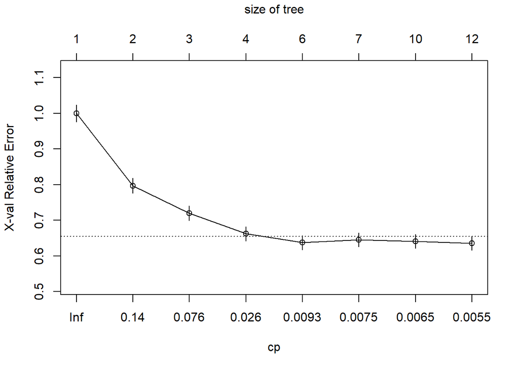

```r
plotcp(dtree_model)
```

Above graph of relative error vs. depth/cp shows that after maxdepth equals 6 there is saturation in error.

## Plotting our tree

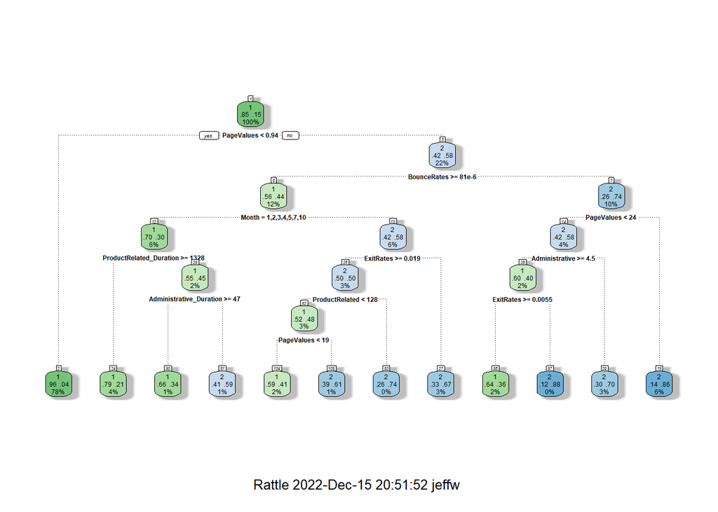

```r
loadPkg("rattle")
fancyRpartPlot(dtree_model)
```

```r
library(pROC)

prob = predict(dtree_model, test, type = "class")
h <- roc(test$Revenue ~ as.numeric(prob))
auc(h) # area-under-curve prefer 0.8 or higher.
```

```
## Area under the curve: 0.751
```

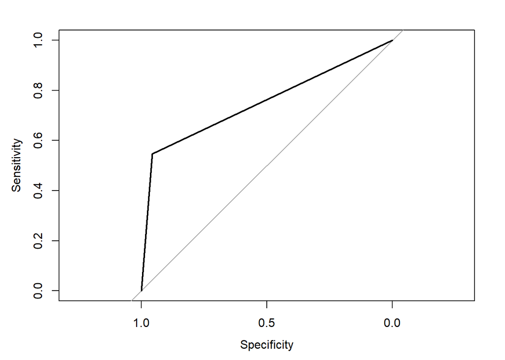

```r
plot(h)
```

Above ROC-AUC analysis shows that imbalance in dataset is not giving good AUC score (<0.8). This is because specificity is much higher than sensitivity.

## Oversampling dataset

Now we will treat our unbalance dataset. True values are very less as compared to False. So we will oversample True observation of Revenue equal to False value for each corresponding variable in dataset.

```r
train_os = data.frame(train)
train_new <- ovun.sample(Revenue ~ ., data = train_os, method = "over",N = 16710)$data
table(train_new$Revenue)
```

```
##
##    1    2
## 8355 8355
```

Above table shows that True and False observations are equal.

## Modeling and Tuning on new balance dataset

```r
confusionMatrixResultDf = data.frame( Depth=numeric(0), Accuracy= numeric(0), Sensitivity=numeric(0), Specificity=numeric(0), Pos.Pred.Value=numeric(0), Neg.Pred.Value=numeric(0), Precision=numeric(0), Recall=numeric(0), F1=numeric(0), Prevalence=numeric(0), Detection.Rate=numeric(0), Detection.Prevalence=numeric(0), Balanced.Accuracy=numeric(0), row.names = NULL )

for (deep in 2:10) {
  tree_fit <- rpart(Revenue ~ . - Region, data=train_new, method="class", control = list(maxdepth = deep, cp=0.001) )

  cm = confusionMatrix( predict(tree_fit, test, type = "class"), reference = test[, "Revenue"], positive = "2")
  cmaccu = cm$overall['Accuracy']

  cmt = data.frame(Depth=deep, Accuracy = cmaccu, row.names = NULL )
  cmt = cbind( cmt, data.frame( t(cm$byClass) ) )
  confusionMatrixResultDf = rbind(confusionMatrixResultDf, cmt)

}

xkabledply(confusionMatrixResultDf, title="Kyphosis Classification Trees summary with varying MaxDepth")
```

| Depth | Accuracy | Sensitivity | Specificity | Pos.Pred.Value | Neg.Pred.Value | Precision | Recall | F1 | Prevalence | Detection.Rate | Detection.Prevalence | Balanced.Accuracy |
| --- | --- | --- | --- | --- | --- | --- | --- | --- | --- | --- | --- | --- |
| 2 | 0.857 | 0.748 | 0.879 | 0.544 | 0.947 | 0.544 | 0.748 | 0.630 | 0.163 | 0.122 | 0.223 | 0.813 |
| 3 | 0.838 | 0.785 | 0.848 | 0.501 | 0.953 | 0.501 | 0.785 | 0.612 | 0.163 | 0.128 | 0.255 | 0.817 |
| 4 | 0.841 | 0.785 | 0.852 | 0.507 | 0.953 | 0.507 | 0.785 | 0.616 | 0.163 | 0.128 | 0.252 | 0.819 |
| 5 | 0.842 | 0.798 | 0.851 | 0.510 | 0.956 | 0.510 | 0.798 | 0.622 | 0.163 | 0.130 | 0.254 | 0.825 |
| 6 | 0.842 | 0.803 | 0.849 | 0.508 | 0.957 | 0.508 | 0.803 | 0.622 | 0.163 | 0.130 | 0.257 | 0.826 |
| 7 | 0.836 | 0.805 | 0.842 | 0.498 | 0.957 | 0.498 | 0.805 | 0.615 | 0.163 | 0.131 | 0.263 | 0.824 |
| 8 | 0.841 | 0.788 | 0.851 | 0.506 | 0.954 | 0.506 | 0.788 | 0.617 | 0.163 | 0.128 | 0.253 | 0.820 |
| 9 | 0.842 | 0.788 | 0.853 | 0.510 | 0.954 | 0.510 | 0.788 | 0.619 | 0.163 | 0.128 | 0.251 | 0.821 |
| 10 | 0.842 | 0.788 | 0.852 | 0.509 | 0.954 | 0.509 | 0.788 | 0.618 | 0.163 | 0.128 | 0.252 | 0.820 |

```r
dtree_model <- rpart(Revenue ~ . - Region, data=train_new, method="class", control = list(maxdepth = 2, cp=0.001) )

confusionMatrix(predict(dtree_model, test, type = "class"), reference = test$Revenue, positive = "2")
```

```
## Confusion Matrix and Statistics
##
##           Reference
## Prediction    1    2
##          1 1816  101
##          2  251  300
##
##                Accuracy : 0.857
##                  95% CI : (0.843, 0.871)
##     No Information Rate : 0.838
##     P-Value [Acc > NIR] : 0.00362
##
##                   Kappa : 0.545
##
##  Mcnemar's Test P-Value : 1.99e-15
##
##             Sensitivity : 0.748
##             Specificity : 0.879
##          Pos Pred Value : 0.544
##          Neg Pred Value : 0.947
##              Prevalence : 0.162
##          Detection Rate : 0.122
##    Detection Prevalence : 0.223
##       Balanced Accuracy : 0.813
##
##        'Positive' Class : 2
##
```

After oversampling our accuracy is 85.7, which is lower than from previous model with unbalanced dataset.

```r
prob = predict(dtree_model, test, type = "class")
# df$prob=prob
h <- roc(test$Revenue ~ as.numeric(prob))
auc(h) # area-under-curve prefer 0.8 or higher.
```

```
## Area under the curve: 0.813
```

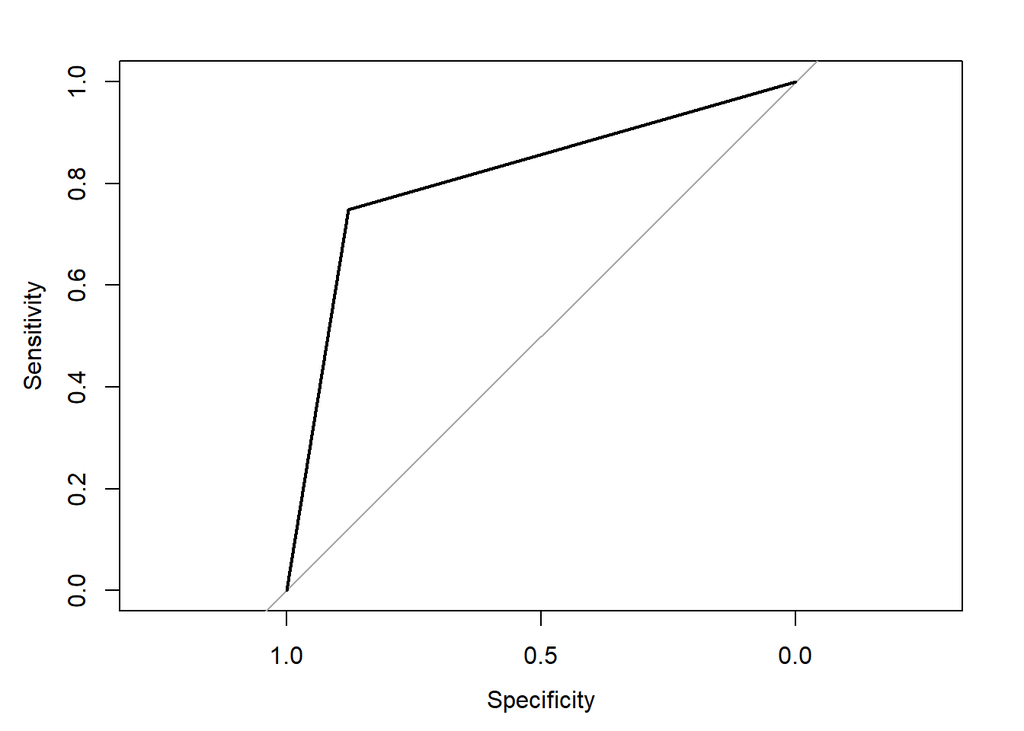

```r
plot(h)
```

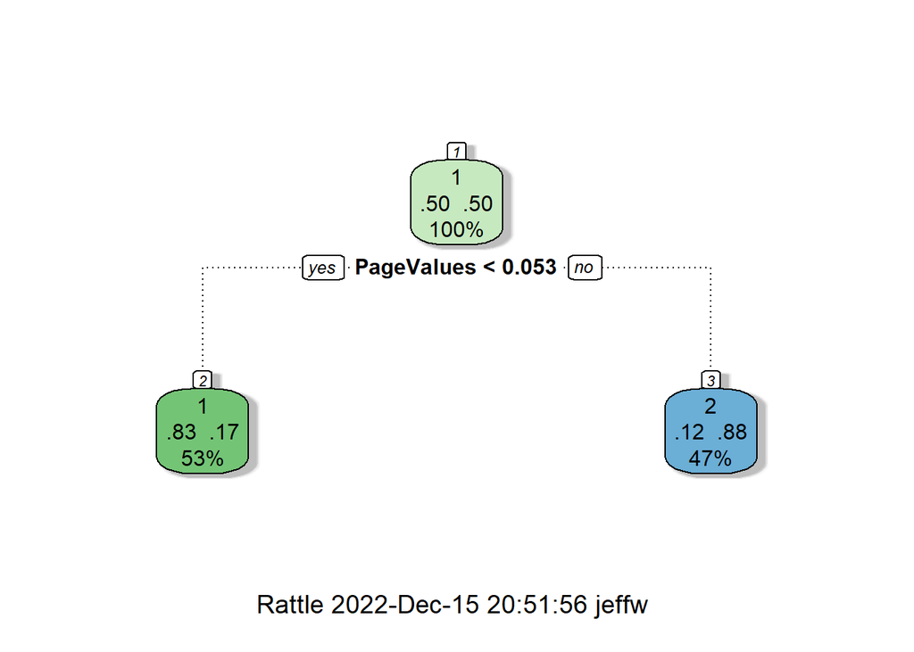

```r
fancyRpartPlot(dtree_model)
```

```r
unloadPkg("Caret")
```

From above two experiments with unbalanced and oversampled (balanced) dataset. When data was unbalanced our accuracy was good ~89% and AUC score was 0.75, which is acceptable. When we oversampled the data it gives us less accuracy but AUC score of 0.81 that is above our 0.8 cutoff. We can make an inference that oversampling is not as beneficial as we thought. The evaluation criteria of AUC score we are using is giving us acceptable value on unbalanced data.

# Aaron’ EDA and KNN Model’

```r
#First, load the file
online = data.frame(read.csv("online_shoppers_intention.csv"))
# We will use this dataframe later for model manipulation
original_online = data.frame(read.csv("online_shoppers_intention.csv"))
total_observations = nrow(online)
total_observations
head(online)
```

[output not shown]

We have read in the data and we have 12,330 observations 18 variables. Just like above we are going to factorize variables that need to be factored fro this part of EDA.

```r
# Handling categorical variables prior to plotting
online$Month = as.factor(online$Month)
online$Revenue = as.factor(online$Revenue)
online$Weekend = as.factor(online$Weekend)
online$VisitorType = as.factor(online$VisitorType)
```

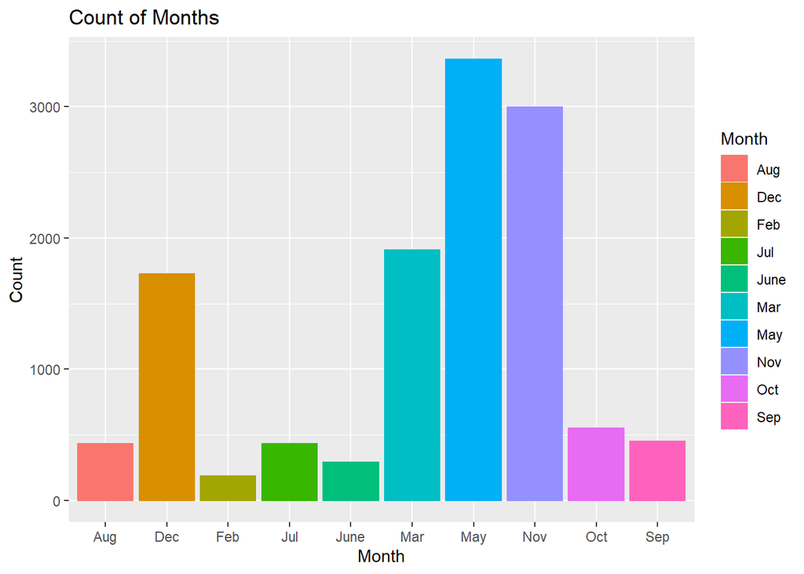

```r
monthFrequency = ggplot(online, aes(x=Month, color=Month, fill=Month)) + geom_bar() + labs(title="Count of Months",
        x ="Month", y = "Count")
monthFrequency
```

We see a good distribution throughout the months in our dataset. One thing to notice is that the months April and January are not represented in our dataset. For the barplot above, the months November and May have the highest count. We do not know the product being sold for the site, but there could be a relationship to the product being sold and the month.

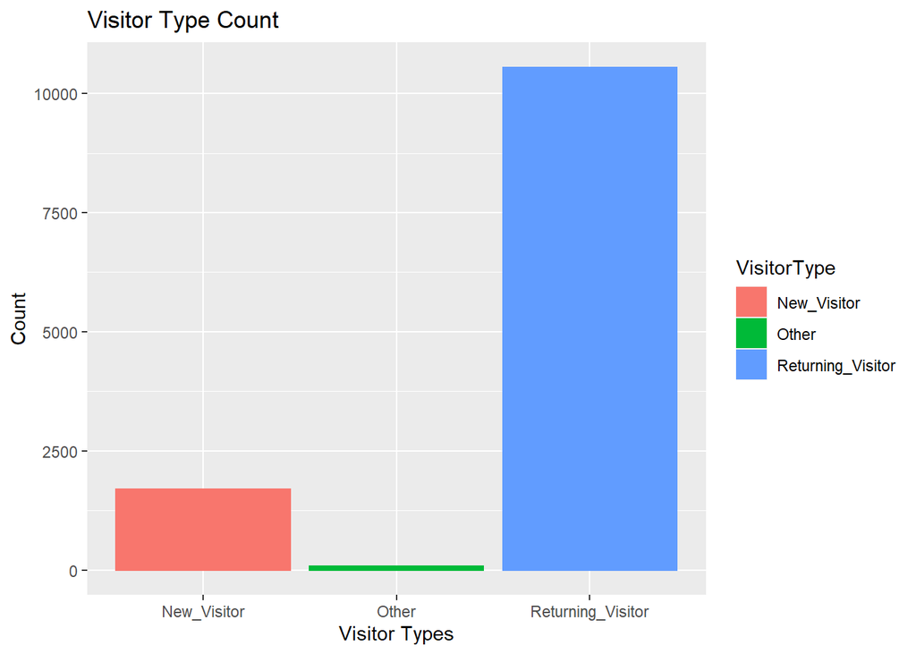

```r
userCount = ggplot(online, aes(x=VisitorType, color=VisitorType, fill=VisitorType)) + geom_bar() + labs(title="Visitor Type Count",
        x ="Visitor Types", y = "Count")
userCount
```

Visitor type is important to any successful webpage. For our specific dataset we see from the plot above that at the time when this dataset was taken that their is a considerable amount of returning customers rather seeing a higher bin for the new visitor.

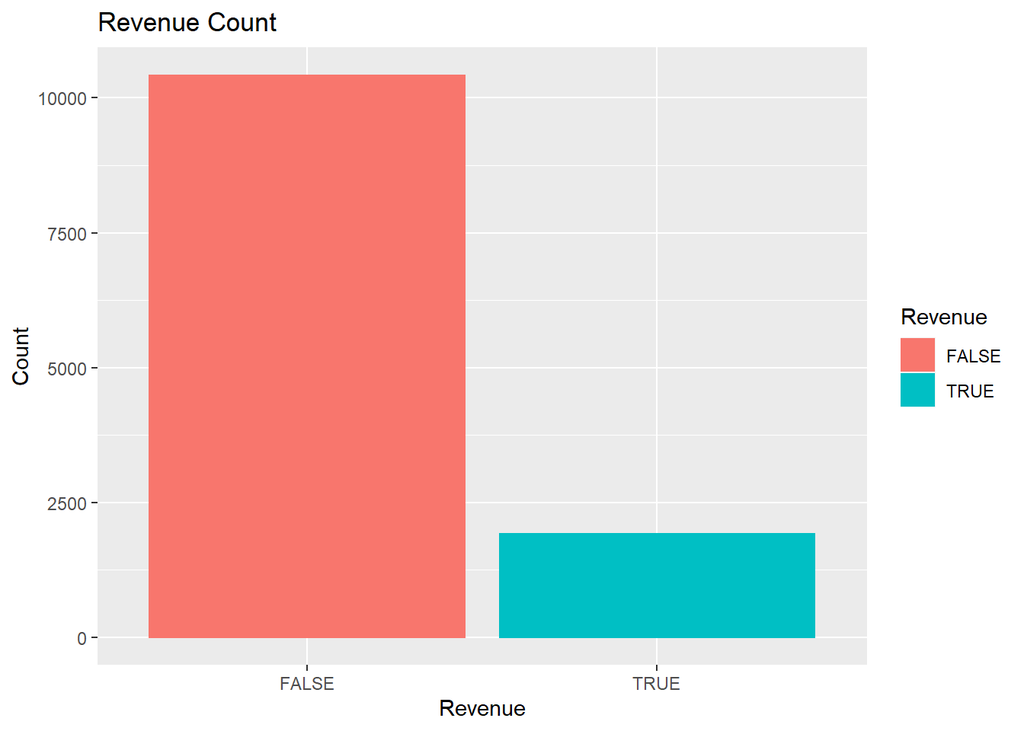

```r
revCount = ggplot(online, aes(x=Revenue, color=Revenue, fill=Revenue)) + geom_bar() + labs(title="Revenue Count",
        x ="Revenue", y = "Count")
revCount
```

The most important variable in our dataset and the variable that will be our target for modeling is revenue. For this variable we can see from the plot above that dataset for this variable is very unbalanced. After viewing the pie chart below the no revenue is at 84.5% and the yes revenue is at 15.5%.

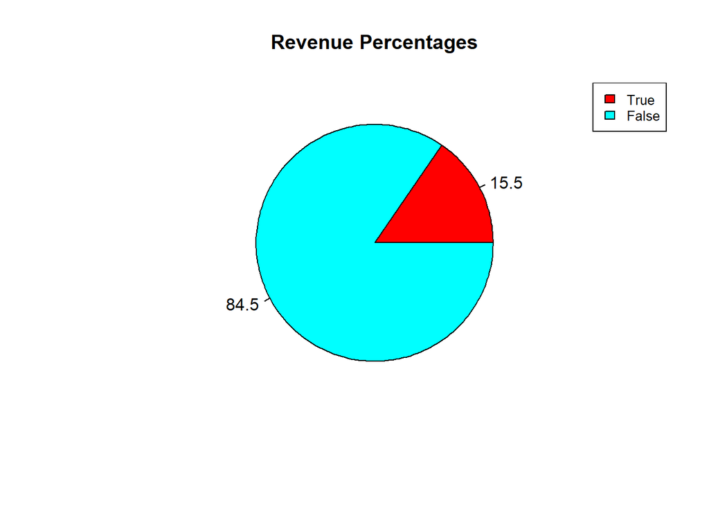

```r
revTrue = subset(online, online$Revenue == TRUE)
revFalse = subset(online, online$Revenue == FALSE)
pieNum <- c(nrow(revTrue), nrow(revFalse))
piepercent<- round(100*pieNum/sum(pieNum), 1)
pie(pieNum, labels = piepercent, main = "Revenue Percentages",col = rainbow(length(pieNum)))
legend("topright", c("True","False"), cex = 0.8, fill = rainbow(length(pieNum)))
```

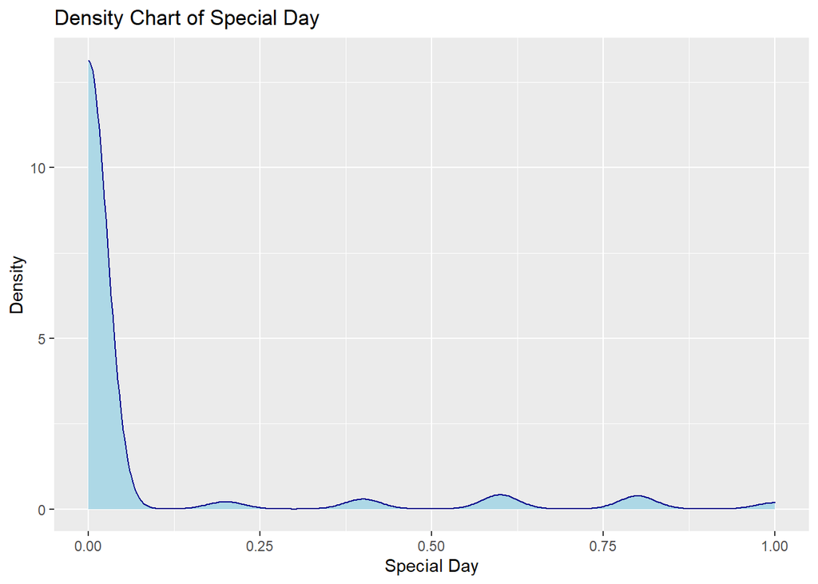

```r
# Special Day data
specialDay = ggplot(online, aes(SpecialDay)) + geom_density(color="darkblue", fill="lightblue") + labs(title="Density Chart of Special Day",x ="Special Day", y = "Density")
specialDay
```

```r
# scatterSpecialDay = ggplot(online, aes(Revenue, SpecialDay)) + geom_violin(), this plot had no significance
```

The special day variable is a measure of how close to a certified holiday the website was visited on. If the number is 0 this means the visit was not close and the closer to 1 being the closer to a holiday it is with 1 being on the day of the special day. When we plot a density chart of this variable we can see that most visits are 0 and the density decreases drastically all the way to 1.

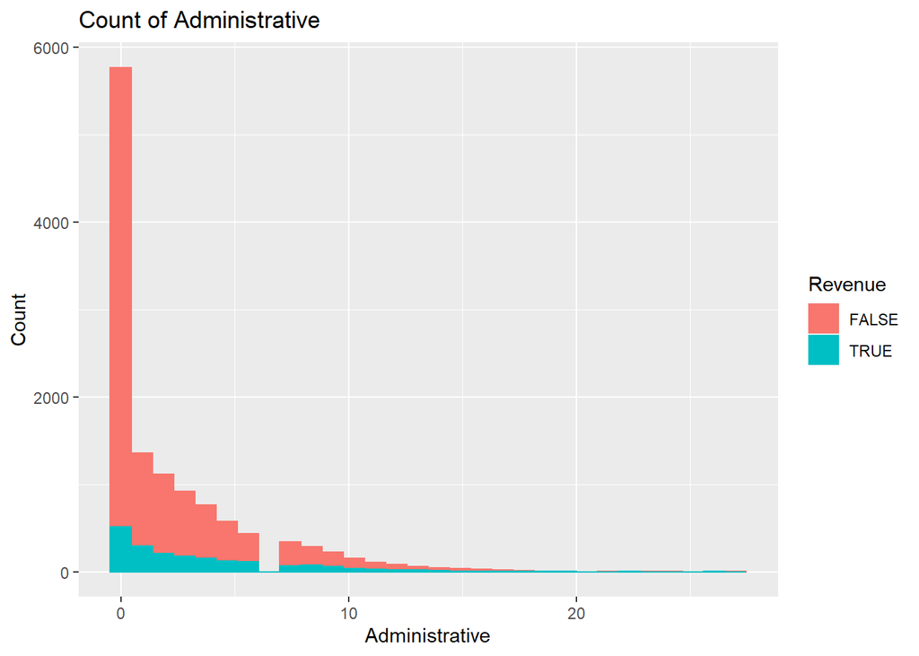

```r
admin = ggplot(online, aes(Administrative, color=Revenue, fill=Revenue)) + geom_histogram(bins=30) + labs(title="Count of Administrative", x ="Administrative", y = "Count")
admin
```

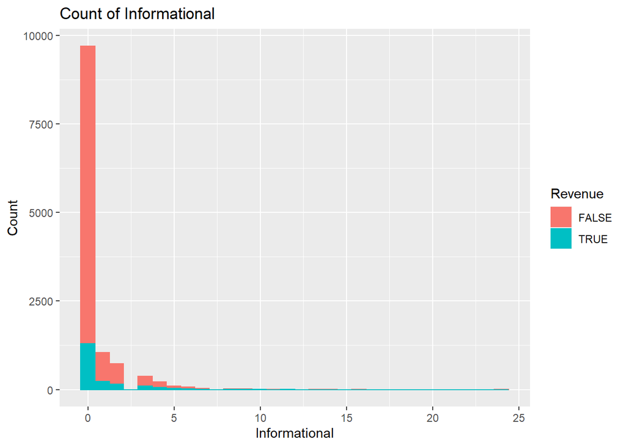

```r
info = ggplot(online, aes(Informational, color=Revenue, fill=Revenue)) + geom_histogram(bins=30) + labs(title="Count of Informational", x ="Informational", y = "Count")
info
```

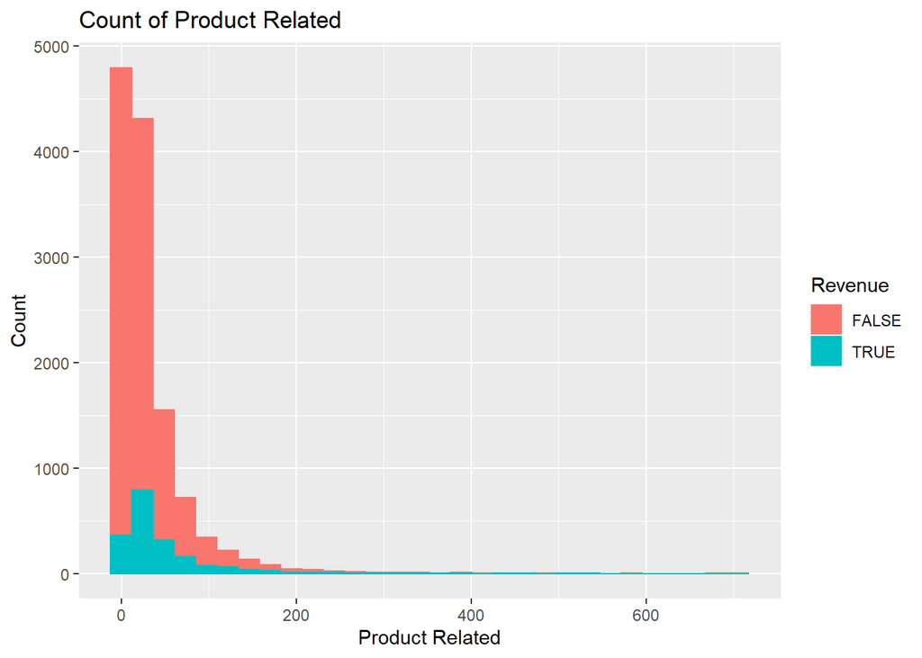

```r
prod = ggplot(online, aes(ProductRelated, color=Revenue, fill=Revenue)) + geom_histogram(bins=30) + labs(title="Count of Product Related", x ="Product Related", y = "Count")
prod
```

The histograms above are the three pages represent on the e-commerce website. For the x-axis it is representing the number of times the user visited this kind of page. The three different pages for the e-commerce are administrative, informational, and product related. The metric we are trying to see from the plots are if there is a correlation between page and revenue. This is why we plotted the revenue classification by color. Administrative and informational seem to not have as much as an impact as product related pages. When we look at the product related page histogram we see that the revenue limbs up the x-axis more than the other two pages.

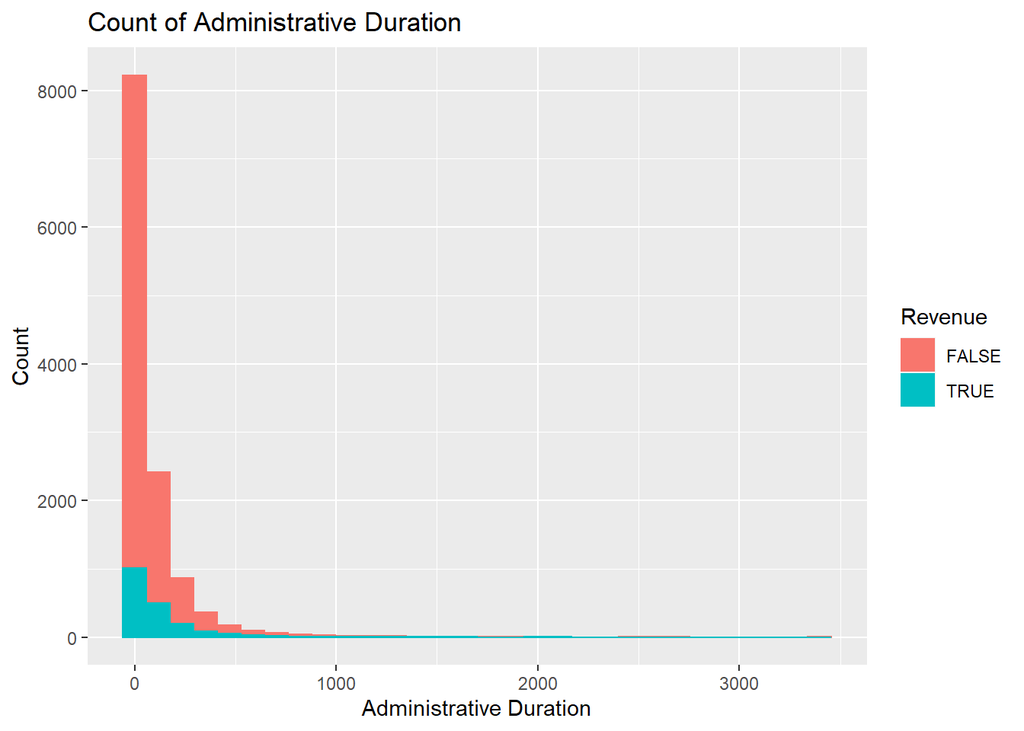

```r
#
# Duration of the above Pages
#
adminDur = ggplot(online, aes(Administrative_Duration, color=Revenue, fill=Revenue)) + geom_histogram(bins=30) + labs(title="Count of Administrative Duration", x ="Administrative Duration", y = "Count")
adminDur
```

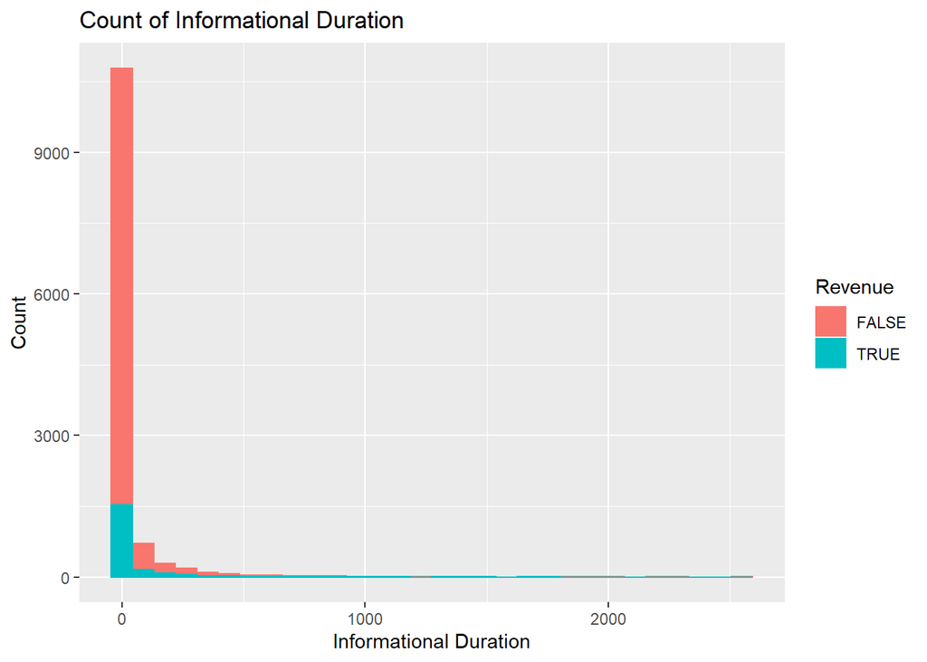

```r
infoDur = ggplot(online, aes(Informational_Duration, color=Revenue, fill=Revenue)) + geom_histogram(bins=30) + labs(title="Count of Informational Duration", x ="Informational Duration", y = "Count")
infoDur
```

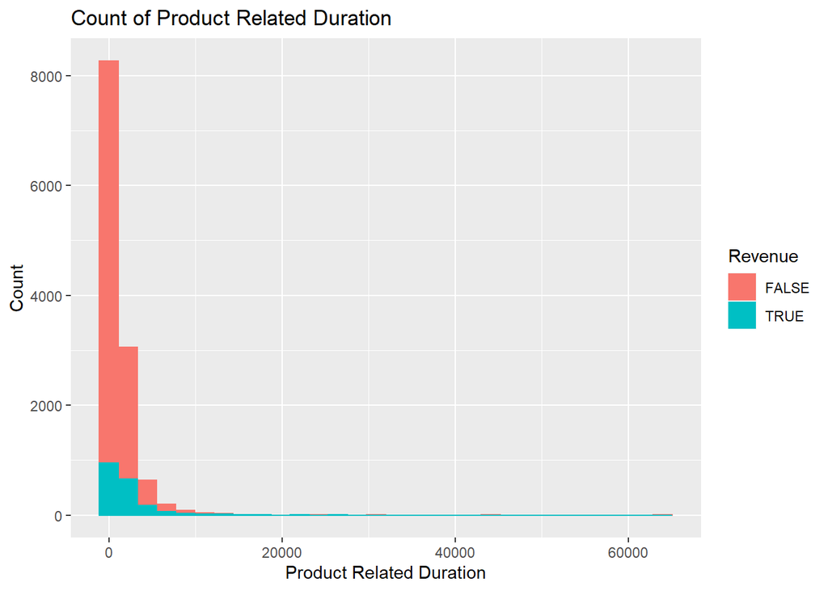

```r
prodDur = ggplot(online, aes(ProductRelated_Duration, color=Revenue, fill=Revenue)) + geom_histogram(bins=30) + labs(title="Count of Product Related Duration", x ="Product Related Duration", y = "Count")
prodDur
```

Just like the variables above these three variables are still about the three main pages on the e-commerce page but instead of counting how many times a customer visits a certain page the plots above use the duration visited on each page. Similar to the plots we saw with count product related is the only histogram with duration that shows any real relationship between time spent on a page and revenue.

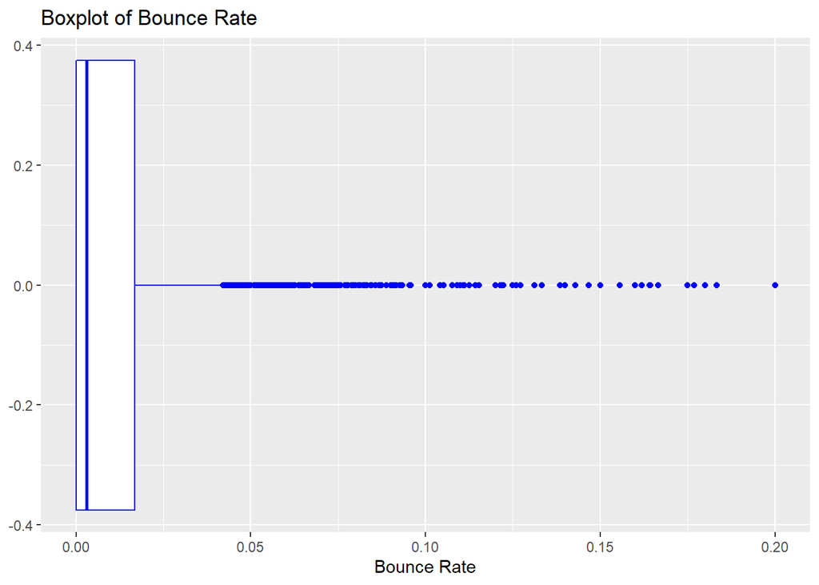

```r
# Bounce Rate is measured by total one page visits divided by total visits
bounceBox = ggplot(online, aes(BounceRates)) + geom_boxplot(color='blue') + labs(title="Boxplot of Bounce Rate", x ="Bounce Rate")
bounceBox
```

The bounce rate for the entire dataset is extremely low indicating that many users are not only viewing one page when visiting the e-commerce website. The interquartile for this variable is below .025. So, 2.5% of all users are viewing one page only before leaving.The average Bounce Rate for this site is 2.219%.

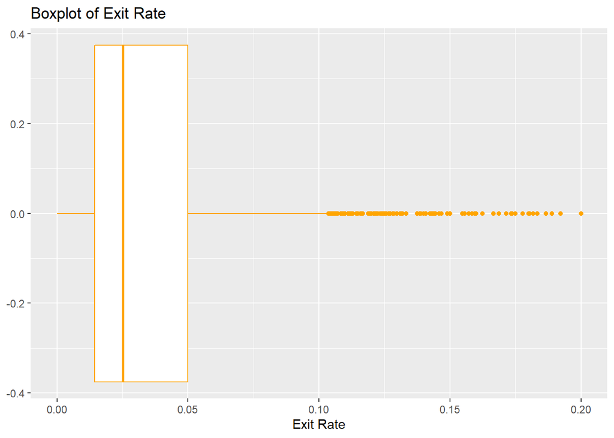

```r
# Exit Rate is measured by total exits from page divided by total visits to page
exitBox = ggplot(online, aes(ExitRates)) + geom_boxplot(color='orange') + labs(title="Boxplot of Exit Rate", x ="Exit Rate")
exitBox
```

For the variable exit rate we are looking to see what is the rate that users are leaving from the site from a specific page. The one down side to our dataset is that the exit rate column is an average of all pages instead of each specific page. With that being said we can see from the boxplot above that the interquartile is right below 0.05. The median looks to be at 0.025. The average Exit Rate for this site is 4.307%.

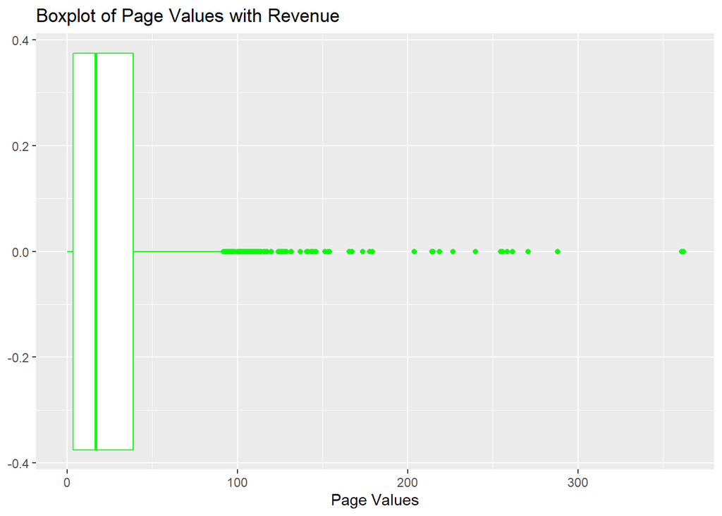

```r
# Page Value is the average value for a page that a user visited before landing on the goal page or completing an E-commerce transaction
pageBox_rev = ggplot(revTrue, aes(PageValues)) + geom_boxplot(color='green') + labs(title="Boxplot of Page Values with Revenue", x ="Page Values")
pageBox_rev
```

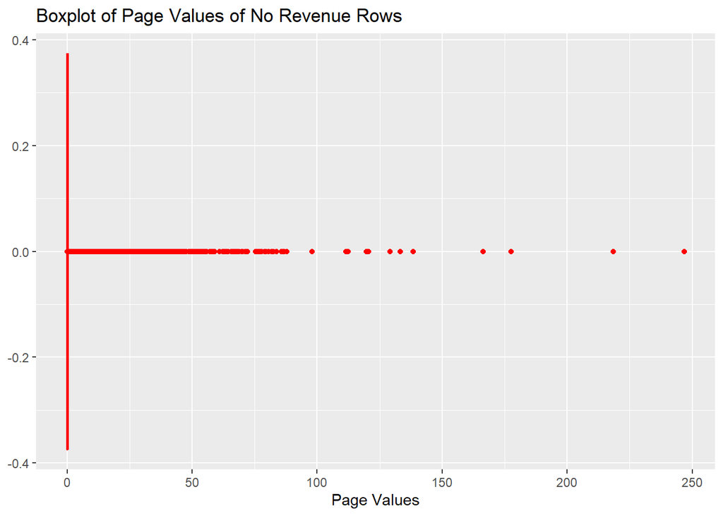

```r
pageBox_no_rev = ggplot(revFalse, aes(PageValues)) + geom_boxplot(color='red') + labs(title="Boxplot of Page Values of No Revenue Rows", x ="Page Values")
pageBox_no_rev
```

To get a valuable insight for the variable page value we split the dataset by if the observation ended with revenue being produced. When we plotted each new subset we can see a massive difference in the interquartiles being plotted on the boxplot. Page Values that had revenue had an average of 27.265. Page Values that had did not have revenue had an average of 1.976.

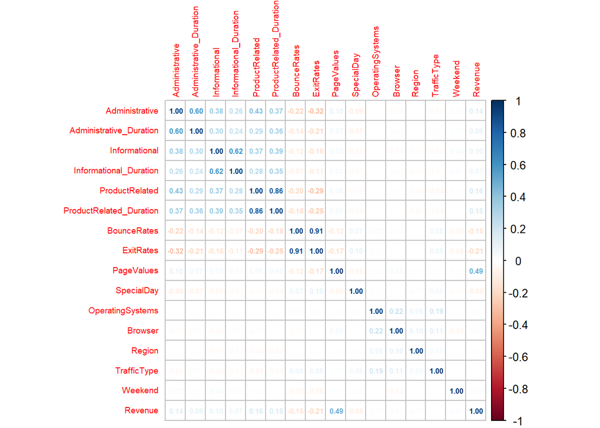

```r
# Corrplot after changing categorical to numerical
online_new = subset(online, select = -c(VisitorType, Month))
online_new$Weekend = as.numeric(online_new$Weekend)
online_new$Revenue = as.numeric(online_new$Revenue)
corrOnline <- cor(online_new)
corrplot(corrOnline, method="number",number.cex=0.5,tl.cex=.6)
```

After reverting back variables to numeric to plot on the corrplot we are able to see a few variables to target when building our model. Page values has the highest correlation at 0.49.

```r
# Table for Month and Revenue of that Month
monthTable = xtabs( ~ Revenue + Month, data = online)
monthTable
chisqMonth = chisq.test(monthTable)
chisqMonth

# Table for Special Day and Revenue as we get closer to that Day
# This value represents the closeness of the browsing date to special days or holidays
specialDayTable = xtabs( ~ Revenue + SpecialDay, data = online)
specialDayTable
chisqSD = chisq.test(specialDayTable)
chisqSD
```

[output not shown]

```r
library(tidyr)
# Rehandle variables for knn model
online$VisitorType = as.factor(online$VisitorType)
online$Weekend = as.integer(online$Weekend)
online$OperatingSystems = as.integer(online$OperatingSystems)
online$Browser = as.integer(online$Browser)
online$TrafficType = as.integer(online$TrafficType)
online$Region = as.integer(online$Region)
online$Month = as.integer(factor(online$Month, levels = month.abb))
online = drop_na(online) # dropping wrong month rows
# Making Visitor Type into numerical variable
library(tidyverse)
online$VisitorType <- str_replace(online$VisitorType,'New_Visitor','1')
online$VisitorType <- str_replace(online$VisitorType,'Other','2')
online$VisitorType <- str_replace(online$VisitorType,'Returning_Visitor','3')
online$VisitorType = as.numeric(online$VisitorType)
```

```r
# handling the variables for the specific variables
# PageValues + Month + ExitRates + ProductRelated_Duration + TrafficType + VisitorType + ProductRelated
original_online$VisitorType = as.factor(original_online$VisitorType)
original_online$Weekend = as.integer(original_online$Weekend)
original_online$OperatingSystems = as.integer(original_online$OperatingSystems)
original_online$Browser = as.integer(original_online$Browser)
original_online$TrafficType = as.integer(original_online$TrafficType)
original_online$Region = as.integer(original_online$Region)
original_online$Month = as.integer(factor(original_online$Month, levels = month.abb))
original_online = drop_na(online)
# Making Visitor Type into numerical variable
original_online$VisitorType <- str_replace(original_online$VisitorType,'New_Visitor','1')
original_online$VisitorType <- str_replace(original_online$VisitorType,'Other','2')
original_online$VisitorType <- str_replace(original_online$VisitorType,'Returning_Visitor','3')
original_online$VisitorType = as.numeric(original_online$VisitorType)
original_online = subset(original_online, select = -c(1,2,3,4,7,10,12,13,14,17))
```

```r
# Scaling
scaledOnline <- as.data.frame(scale(online[1:17], center = TRUE, scale = TRUE))

# Selected Variables based off EDA - Scaling
scaled_Online_select <- as.data.frame(scale(original_online[1:7], center = TRUE, scale = TRUE))

set.seed(123)
online_sample <- sample(2, nrow(scaledOnline), replace=TRUE, prob=c(0.80, 0.20))

# Selected Variables Model based off EDA
set.seed(123)
online_sample_selected <- sample(2, nrow(scaled_Online_select), replace=TRUE, prob=c(0.8, 0.2))

online_training <- scaledOnline[online_sample==1, 1:17]
online_test <- scaledOnline[online_sample==2, 1:17]

# Selected Variables Model based off EDA
online_training_selected <- scaled_Online_select[online_sample_selected==1, 1:7]
online_test_selected <- scaled_Online_select[online_sample_selected==2, 1:7]

online_trainLabels <- online[online_sample==1, 18]
online_testLabels <- online[online_sample==2, 18]

# Selected Variables Model based off EDA
online_trainLabels_selected <- original_online[online_sample_selected==1, 8]
online_testLabels_selected <- original_online[online_sample_selected==2, 8]
```

Before applying our dataset to the model we have split the data into x values and a y target. The y target for this datset is revenue. We did a 4 to 1 split of the dataset and will have two models. One model will utilize every variable on the dataset. The other model is using variables that are significant to the outcome for revenue. After EDA and certain statistical tests the relevant variables are page values, month, exit rates, product related duration, traffic type, visitor type, and product related.

```r
ResultDf = data.frame( k=numeric(0), Total.Accuracy= numeric(0), row.names = NULL )

ResultDf_selected = data.frame( k=numeric(0), Total.Accuracy= numeric(0), row.names = NULL )
```